# Week 3 Problem Sheet

Akasha Strub

18 July 2023

## Import libraries

```r
# Import libraries
library(rethinking)
library(dplyr)
library(ggplot2)
library(dagitty)

# Set seed
set.seed(1807)
```

## Problem 1

DAG:

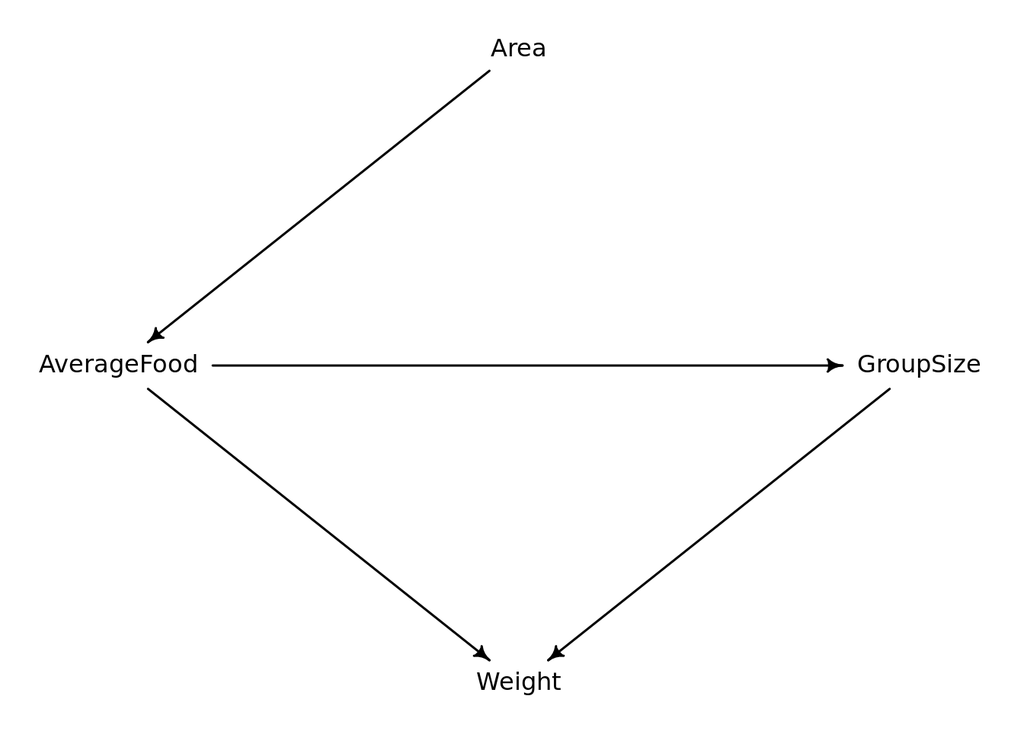

```r
# Draw DAG
# F is avgfood, G is groupsize, A is area, and W is weight.
dag <- dagitty( "dag {
Area -> AverageFood
AverageFood -> Weight
AverageFood -> GroupSize
GroupSize -> Weight
}")

coordinates(dag) <- list(
  x = c(Weight = 1, AverageFood = 0, GroupSize = 2, Area = 1) ,
  y = c(Weight = 2, AverageFood = 1, GroupSize = 1, Area = 0))

drawdag(dag)
```

Use the backdoor criterion and estimate the total causal influence of A on F. What effect would increasing the area of a territory have on the amount of food inside it?

```r
# No backdoor criterion is required, as nothing else feeds into F.
# A simple bivariate regression will do.

# Load data
data(foxes)

# Standardize data
df1 <- foxes %>%
  mutate(avgfood_std = standardize(avgfood),
         groupsize_std = standardize(groupsize),
         area_std = standardize(area),
         weight_std = standardize(weight))

# Find association between area and average food
model1 <- quap(
  alist(
    avgfood_std ~ dnorm(mu, sigma),
    mu <- a + b*area_std,
    a ~ dnorm( 0 , 1 ),
    b ~ dnorm( 0 , 1 ),
    sigma ~ dexp( 1 )
    ),
  data = df1)

# Posterior marginal distributions
precis(model1)
```

```
##               mean         sd        5.5%     94.5%
## a     4.716130e-07 0.04324479 -0.06911306 0.0691140
## b     8.814336e-01 0.04343260  0.81201994 0.9508473
## sigma 4.661968e-01 0.03051315  0.41743088 0.5149627
```

Looks like territory size has a strong effect on average food. The larger the territory, the larger the average food.

## Problem 2

Infer the total causal effect of adding food F to a territory on the weight W of foxes. Can you calculate the causal effect by simulating an intervention on food?

```r
# The total causal effect is a combination of the direct path and the indirect
# path flowing from F to W. Therefore, this is once again a simple bivariate
# regression problem.

# Find association (total causal effect) between food and weight
model2 <- quap(
  alist(
    weight_std ~ dnorm(mu, sigma),
    mu <- a + b*avgfood_std,
    a ~ dnorm( 0 , 1 ),
    b ~ dnorm( 0 , 1 ),
    sigma ~ dexp( 1 )
    ),
  data = df1)

# Posterior marginal distributions
precis(model2)
```

```
##                mean         sd       5.5%     94.5%
## a      8.385246e-08 0.09163813 -0.1464553 0.1464555
## b     -2.482681e-02 0.09203234 -0.1719123 0.1222586
## sigma  9.911432e-01 0.06465846  0.8878065 1.0944799
```

These results suggest that there is no effect from increasing average food on weight.

## Problem 3

Infer the direct causal effect of adding food F to a territory on the weight W of foxes. In light of your estimates from this problem and the previous one, what do you think is going on with these foxes?

```r
# To infer the DIRECT causal effect, we need to also include groupsize G in the
# model, and thereby graduate model2 to a multivariate model.

# Find CONDITIONAL association between weight and average food and groupsize
model3 <- quap(
  alist(
    weight_std ~ dnorm(mu, sigma),
    mu <- a + b_avgfood*avgfood_std + b_groupsize*groupsize_std,
    a ~ dnorm( 0 , 1 ),
    b_avgfood ~ dnorm( 0 , 1 ),
    b_groupsize ~ dnorm( 0 , 1 ),
    sigma ~ dexp( 1 )
    ),
  data = df1)

# Posterior marginal distributions
precis(model3)
```

```
##                      mean         sd       5.5%      94.5%
## a            5.177326e-07 0.08690203 -0.1388857  0.1388868
## b_avgfood    5.914120e-01 0.19541329  0.2791038  0.9037201
## b_groupsize -6.888536e-01 0.19541487 -1.0011643 -0.3765429
## sigma        9.395179e-01 0.06134174  0.8414819  1.0375538
```

One possible interpretation:

Conditional on a fixed group size, an increase in average food increases the weight of the foxes. This is intuitive as there is more food per fox, leading to an increase in weight.

Conditional on fixed average food, an increase in group size causes a decrease in the weight of the foxes. This is also intuitive as there is less food per fox, leading to a decrease in weight.

These variables have an opposite effect on the output, weight. When assessing the total causal effect of average food on weight (`model2`), we saw no association. One possible interpretation is that the effect of these two variables balance out. Wherever there is more average food, there will be more foxes in a group. Essentially, the ecosystem is balanced such that food per fox is constant across groups. Let’s check this our very quickly.

```r
# Find CONDITIONAL association between weight and average food and groupsize
model3b <- quap(
  alist(
    groupsize_std ~ dnorm(mu, sigma),
    mu <- a + b_avgfood*avgfood_std,
    a ~ dnorm( 0 , 1 ),
    b_avgfood ~ dnorm( 0 , 1 ),
    sigma ~ dexp( 1 )
    ),
  data = df1)

# Posterior marginal distributions
precis(model3b)
```

```
##                    mean         sd        5.5%      94.5%
## a         -6.191704e-07 0.03990654 -0.06377897 0.06377774
## b_avgfood  9.000349e-01 0.04007984  0.83597953 0.96409018
## sigma      4.301492e-01 0.02816195  0.38514099 0.47515745
```

This looks to indeed be the case: As average food increases, so does the number of foxes in a group. Nature is balancing this all out.